# ps_4.Rmd

Hamaad Mehal

3/5/2020

# Mad Libs

Treasure County, Montana is located in the state of Montana.

# Question 2

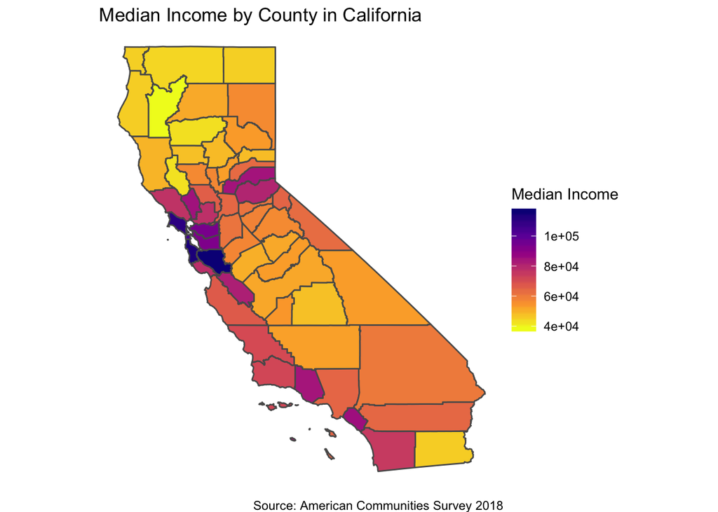

# Question 3

The necessary information for this is in the ps_4_rpub.Rmd that I have also committed. This is the link: https://rpubs.com/hamaadwmehal/582059

# Question 4

This powerpoint lacks information. Tax information isn’t presented in an informative. It focuses on many elements tax code in a convoluted manner, so the explanations prove weak for readers. This skips the nuances of tax code and does not provide context to readers that allows them to understand the situation. The bullet points create their own stories that make an incoherent presentation. The attempts at logic are not subtantial from substance- driven perspective and works in a very biased way. There is a whole lack of substance because of a pursuit to make graphs look good.. This data does not truly explaing the tax system of California, and it doesn’t argue for the validity of California’s tax structure. Since the information and the arguments don’t seem to overlap much, the data contributes little to an argument in favor of California’s tax system which makes the visualizations somewhat obsolete. This data is not novel for those who know the tax system but doesn’t provide any information to those unfamiliar with it, making it a net negative all around.

# 5A

```
## [1] "f"
```

# 5B

```
## [1] "f" "k" "a"
```

# 5C

| throws |
| --- |
| j, a, q, e |
| a, i, c, l |
| a, g, c, f |
| i, j, m, q |
| q, a, e, u |

# 5D

0.005. This is a significantly small number.

# 5E

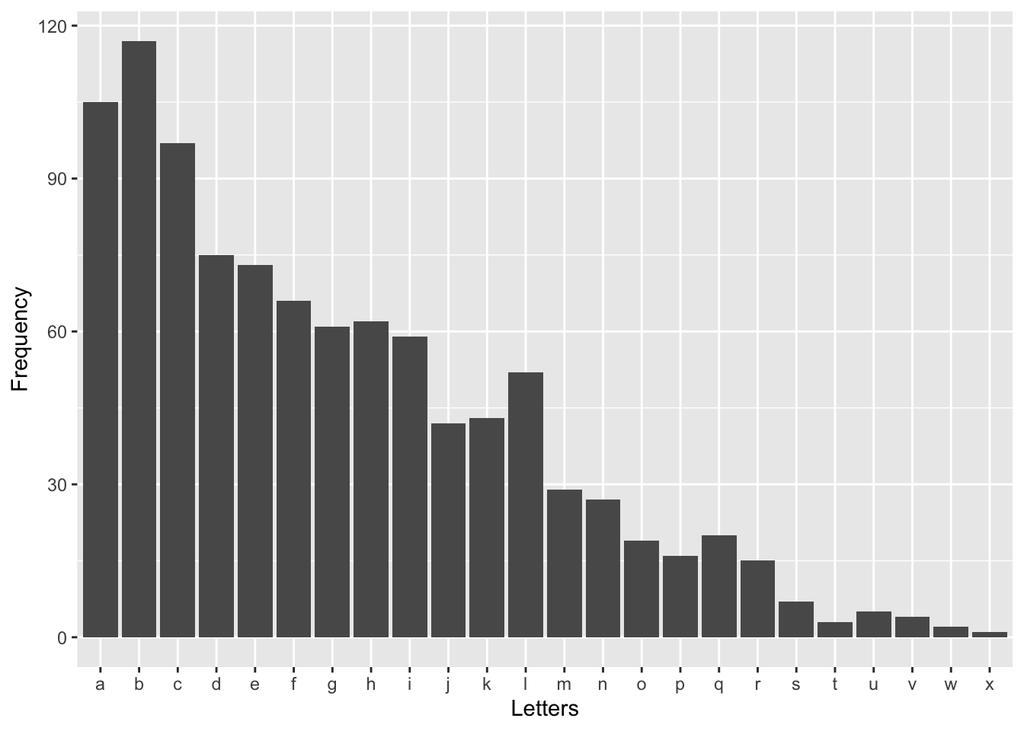

# 5F

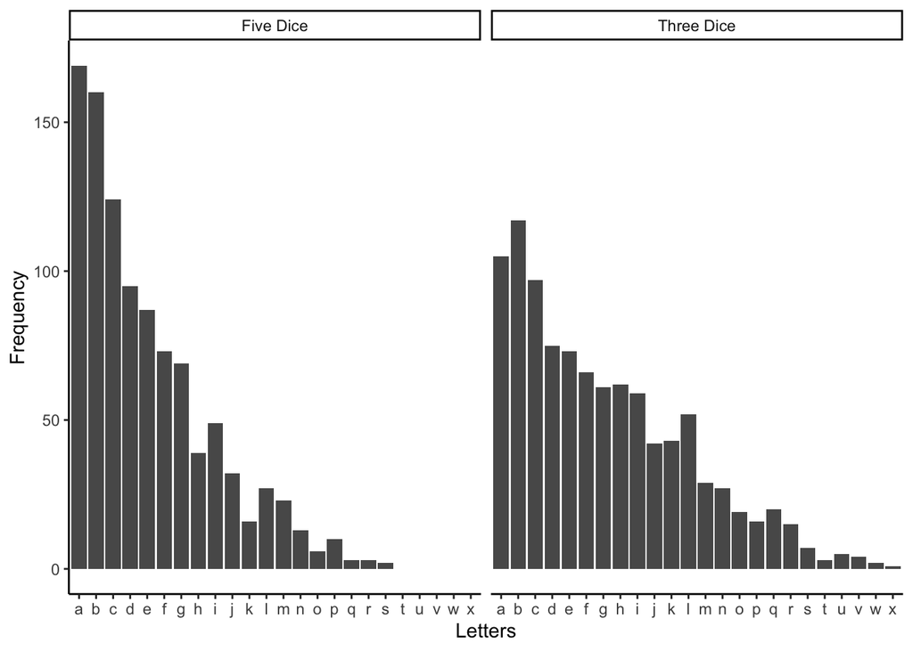

Collaborators: Ibraheem Khan, Asmer Safi, Jun Yung Kim